# Projekt

Autor

Anastasiia Ivashchenko

Nasza analiza skupia się na zbiorze danych, który stanowi źródło informacji o uczniach klas maturalnych z dwóch portugalskich szkół. W ramach tego projektu badawczego, uwagę zwracamy na uczniów, którzy uczęszczają do klas matematycznych i humanistycznych.

Dane, które poddajemy szczegółowej analizie, zostały zebrane w etyczny sposób. Każdy uczeń uczestniczący w badaniu wypełnił obowiązkową ankietę, która była w pełni anonimowa.

Zbiór danych zawiera różnorodne informacje, które mogą pomóc zrozumieć wiele aspektów edukacji i rozwoju młodzieży. Analizujemy takie rzeczy jak wyniki w nauce, relacje w rodzinie, zachowanie w grupie i opinie o szkole. Dzięki temu możemy lepiej zrozumieć, jak edukacja wpływa na młodych ludzi oraz jakie czynniki mogą wpływać na ich sukcesy i trudności w szkole.

| school | Cours | sex | age | address | famsize | Pstatus | Medu | Fedu | Mjob | Fjob | reason | guardian | traveltime | studytime | failures | schoolsup | famsup | paid | activities | nursery | higher | internet | romantic | famrel | freetime | goout | Dalc | Walc | health | … |
| --- | --- | --- | --- | --- | --- | --- | --- | --- | --- | --- | --- | --- | --- | --- | --- | --- | --- | --- | --- | --- | --- | --- | --- | --- | --- | --- | --- | --- | --- | --- |
| GP | Portugese | F | 15 | U | LE3 | T | 1 | 1 | at_home | other | other | mother | 1 | 2 | 0 | yes | no | no | no | yes | yes | yes | no | 4 | 3 | 2 | 2 | 3 | 3 | … |
| GP | Portugese | F | 15 | U | GT3 | T | 4 | 2 | health | services | home | mother | 1 | 3 | 0 | no | yes | no | yes | yes | yes | yes | yes | 3 | 2 | 2 | 1 | 1 | 5 | … |
| GP | Portugese | M | 15 | U | LE3 | A | 3 | 2 | services | other | home | mother | 1 | 2 | 0 | no | yes | no | no | yes | yes | yes | no | 4 | 2 | 2 | 1 | 1 | 1 | … |
| GP | Portugese | M | 15 | U | GT3 | T | 3 | 4 | other | other | home | mother | 1 | 2 | 0 | no | yes | no | yes | yes | yes | yes | no | 5 | 5 | 1 | 1 | 1 | 5 | … |
| GP | Portugese | F | 16 | U | GT3 | T | 3 | 3 | other | other | home | father | 1 | 2 | 0 | no | yes | no | no | yes | yes | no | no | 4 | 3 | 2 | 1 | 2 | 5 | … |
| GP | Portugese | M | 16 | U | LE3 | T | 4 | 3 | services | other | reputation | mother | 1 | 2 | 0 | no | yes | no | yes | yes | yes | yes | no | 5 | 4 | 2 | 1 | 2 | 5 | … |
| GP | Portugese | M | 16 | U | LE3 | T | 2 | 2 | other | other | home | mother | 1 | 2 | 0 | no | no | no | no | yes | yes | yes | no | 4 | 4 | 4 | 1 | 1 | 3 | … |
| GP | Portugese | F | 17 | U | GT3 | T | 1 | 1 | at_home | other | course | father | 1 | 2 | 0 | no | yes | no | no | no | yes | yes | no | 5 | 3 | 3 | 1 | 1 | 3 | … |
| GP | Portugese | F | 17 | U | GT3 | A | 4 | 4 | other | teacher | home | mother | 2 | 2 | 0 | yes | yes | no | no | yes | yes | no | no | 4 | 1 | 4 | 1 | 1 | 1 | … |
| GP | Portugese | F | 18 | U | GT3 | A | 4 | 4 | at_home | teacher | course | mother | 2 | 2 | 0 | yes | no | no | no | yes | yes | no | no | 4 | 3 | 4 | 1 | 1 | 3 | … |

W zbiorze danych są takie informacje:

*school* - szkoła ucznia (binary: ‘GP’ - Gabriel Pereira lub ‘MS’ - Mousinho da Silveira)

*cours* - Przedmiot rozszerzony

*sex* - płeć ucznia (binary: ‘F’ - kobieta lub ‘M’ - mężczyzna)

*age* - wiek ucznia (numeric: od 15 do 22 lat)

*address* - typ adresu domowego ucznia (binary: ‘U’ - miejski (urban) lub ‘R’ - wiejski (rural))

*famsize* - wielkość rodziny (binary: ‘LE3’ - równa lub mniejsza niż 3 lub ‘GT3’ - większa niż 3)

*Pstatus* - status współżycia rodziców (binary: ‘T’ - mieszkają razem (together) lub ‘A’ - osobno (apart))

*Medu* - wykształcenie matki (numeric: 0 - brak, 1 - podstawowe (4 klasy), 2 – od 5 do 9 klasy, 3 – średnie lub 4 – wyższe)

*Fedu* - wykształcenie ojca (numeric: 0 - brak, 1 - podstawowe (4 klasy), 2 – od 5 do 9 klasy, 3 – średnie lub 4 – wyższe)

*Mjob* - zawód matki (nominal: ‘teacher’, ‘health’ care related, civil ‘services’ (e.g. administrative or police), ‘at_home’ lub ‘other’)

*Fjob* - zawód ojca (nominal: ‘teacher’, ‘health’ care related, civil ‘services’ (e.g. administrative or police), ‘at_home’ lub ‘other’)

*reason* - powód wyboru tej szkoły nominal: close to ‘home’, school ‘reputation’, ‘course’ preference lub ‘other’)

*guardian* - opiekun ucznia (nominal: ‘mother’, ‘father’ lub ‘other’)

*traveltime* - czas dojazdu z domu do szkoły (numeric: 1 - <15 min., 2 - 15 do 30 min., 3 - 30 min. do 1 godziny, lub 4 - >1 godzina)

*studytime* - tygodniowy czas nauki (numeric: 1 - <2 godziny, 2 - 2 do 5 godzin, 3 - 5 do 10 godzin, lub 4 - >10 godzin)

*failures* - liczba niezdanych klas w przeszłości (numeric: n jeśli 1<=n<3, w przeciwnym razie 4)

*schoolsup* - dodatkowe wsparcie edukacyjne (binary: tak lub nie)

*famsup* - wsparcie edukacyjne rodziny (binary: tak lub nie)

*paid* - dodatkowe płatne zajęcia w ramach przedmiotu kursu (Matematyka lub Portugalski) (binary: tak lub nie)

*activities* - zajęcia pozalekcyjne (binary: tak lub nie)

*nursery* - uczęszczanie do przedszkola (binary: tak lub nie)

*higher* - chęć podjęcia wyższego wykształcenia (binary: tak lub nie)

*internet* - dostęp do Internetu w domu (binary: tak lub nie)

*romantic* - w związku romantycznym (binary: tak lub nie)

*famrel* - jakość relacji rodzinnych (numeric: od 1 - bardzo złe do 5 - doskonałe)

*freetime* - czas wolny po szkole (numeric: od 1 - bardzo mało do 5 - bardzo dużo)

*goout* - wychodzenie z przyjaciółmi (numeric: od 1 - bardzo rzadko do 5 - bardzo często)

*Dalc* - konsumpcja alkoholu w dni powszednie (numeric: od 1 - bardzo niska do 5 - bardzo wysoka)

*Walc* - konsumpcja alkoholu w weekendy (numeric: od 1 - bardzo niska do 5 - bardzo wysoka)

*health* - aktualny stan zdrowia (numeric: od 1 - bardzo zły do 5 - bardzo dobry)

*absences* - liczba nieobecności w szkole (numeric: od 0 do 75)

Te oceny są związane z przedmiotem kursu, Matematyką lub Portugalskim:

*G1* - ocena za pierwszy okres (numeric: od 0 do 20)

*G2* - ocena za drugi okres (numeric: od 0 do 20)

*G3* - ocena końcowa (numeric: od 0 do 20, cel wyjściowy)

### Analiza brakujących danych

Została przeprowadzona szczegółowa analiza w poszukiwaniu brakujących wartości w dostarczonym zbiorze danych. Na podstawie przeprowadzonej inspekcji stwierdzono, że w zbiorze nie występują braki danych.

### Analiza powtarzających się rekordów

Dokonano analizy zbioru pod kątem obecności powtarzających się wierszy. Po przeprowadzeniu tej analizy stwierdzono, że zbiór nie zawiera duplikatów i każdy rekord jest unikalny.

### Podstawowe statystyki dla kolumn numerycznych

| Statistic | age | Medu | Fedu | traveltime | studytime | failures | famrel | freetime | goout | Dalc | Walc | health | absences | G1 | G2 | G3 |
| --- | --- | --- | --- | --- | --- | --- | --- | --- | --- | --- | --- | --- | --- | --- | --- | --- |
| Min. | 15.00 | 0.0 | 0.00 | 1.00 | 1.00 | 0.00 | 1.00 | 1.0 | 1.00 | 1.00 | 1.00 | 1.00 | 0.00 | 0.00 | 0.00 | 0.00 |
| 1st Qu. | 16.00 | 2.0 | 1.00 | 1.00 | 1.00 | 0.00 | 4.00 | 3.0 | 2.00 | 1.00 | 1.00 | 3.00 | 0.00 | 9.00 | 9.00 | 10.00 |
| Median | 17.00 | 3.0 | 2.00 | 1.00 | 2.00 | 0.00 | 4.00 | 3.0 | 3.00 | 1.00 | 2.00 | 4.00 | 2.00 | 11.00 | 11.00 | 11.00 |
| Mean | 16.73 | 2.6 | 2.39 | 1.52 | 1.97 | 0.26 | 3.94 | 3.2 | 3.16 | 1.49 | 2.28 | 3.54 | 4.43 | 11.21 | 11.25 | 11.34 |
| 3rd Qu. | 18.00 | 4.0 | 3.00 | 2.00 | 2.00 | 0.00 | 5.00 | 4.0 | 4.00 | 2.00 | 3.00 | 5.00 | 6.00 | 13.00 | 13.00 | 14.00 |
| Max. | 22.00 | 4.0 | 4.00 | 4.00 | 4.00 | 3.00 | 5.00 | 5.0 | 5.00 | 5.00 | 5.00 | 5.00 | 75.00 | 19.00 | 19.00 | 20.00 |

### Wykresy dla kolumn numerycznych

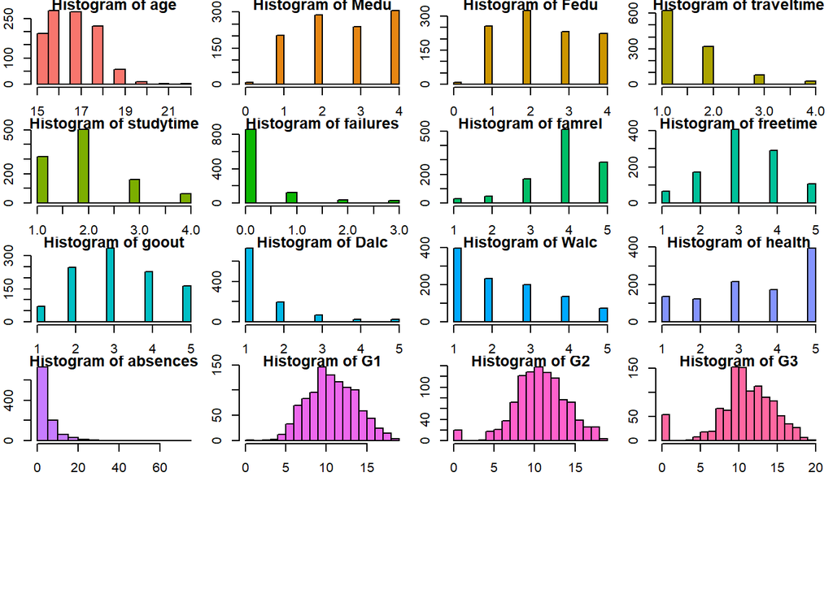

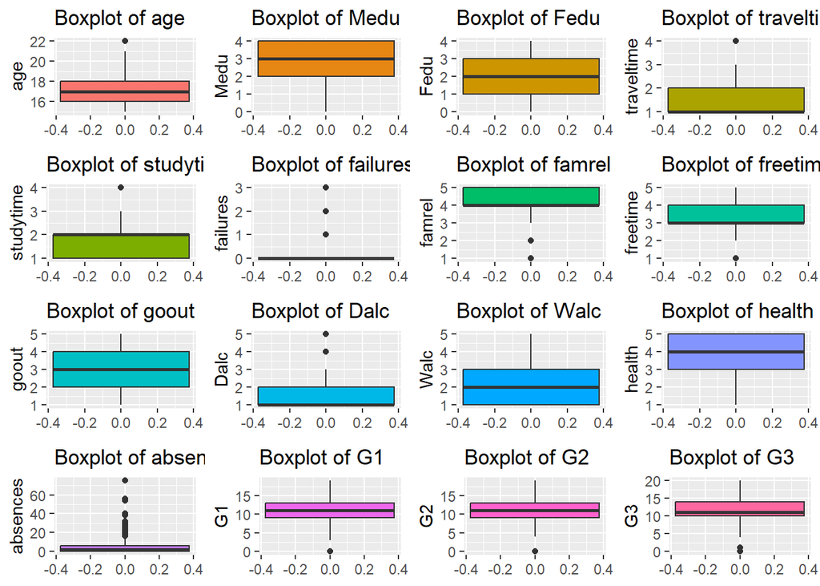

#### Oto kilka interesujących obserwacji, które można wywnioskować z podanych wykresów:

- **Rozkład wieku**: Większość uczniów jest w wieku 15-18 lat, z niewielką liczbą uczniów w wieku 19-22 lat.
- **Wykształcenie rodziców**: Wydaje się, że wiele matek ma wyższe wykształcenie w porównaniu z ojcami.
- **Czas dojazdu**: Większość uczniów ma krótki czas dojazdu do szkoły, co jest zgodne z wcześniejszymi obserwacjami.
- **Czas nauki**: Większość uczniów poświęca średnią ilość czasu na naukę.
- **Niepowodzenia**: Jak wcześniej zauważono, większość uczniów ma niewiele lub wcale niepowodzeń.
- **Jakość relacji rodzinnych, czas wolny, wychodzenie z przyjaciółmi, spożycie alkoholu, stan zdrowia**: Histogramy tych zmiennych prezentują się w sposób oczekiwany na podstawie wcześniejszej analizy.
- **Nieobecności**: Większość uczniów ma niewiele nieobecności, ale istnieje pewna liczba uczniów z dużą liczbą nieobecności.
- **Oceny** (G1, G2, G3): Rozkład ocen jest stosunkowo normalny z nieco lepszymi wynikami w trzecim okresie.

### Macierz korelacji dla kolumn numerycznych

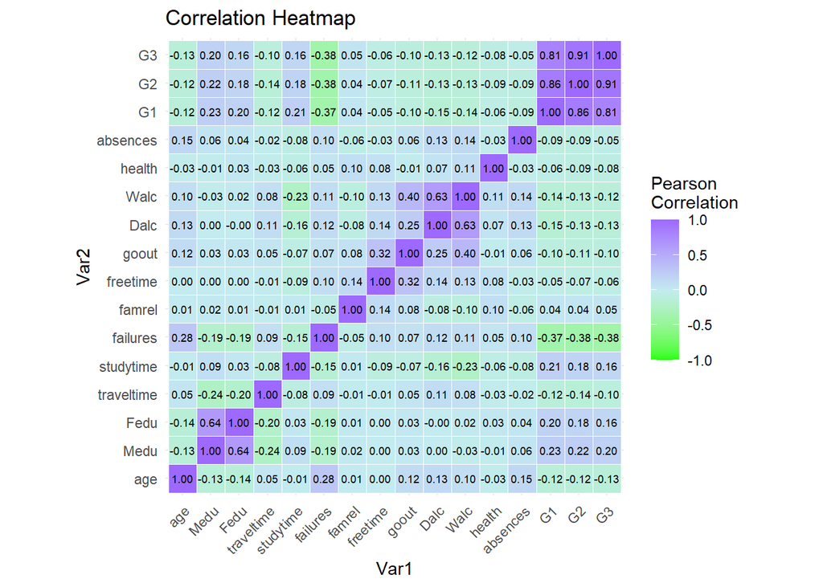

#### Oto kilka interesujących obserwacji, które można wywnioskować z podanej macierzy korelacji:

- Możemy zauważyć, że zmienne **Fedu** (wykształcenie ojca)i **Medu** (wykształcenie matki) wykazują silną pozytywną korelację.

Z tego można wywnioskowć, że ludzie o podobnym poziomie wykształcenia mogą pochodzić z podobnych środowisk kulturowych lub społecznych, co może wpływać na ich wybory życiowe, w tym wybór partnera. W rodzinach, gdzie matka ma wysoki poziom wykształcenia, jest większa szansa, że ojciec również będzie miał wysoki poziom wykształcenia, i odwrotnie. Może to sugerować, że ludzie z podobnym poziomem wykształcenia mają tendencję do łączenia się w pary.

- Możemy zauważyć, że zmienne **Walc** (spożycie alkoholu w weekendy) i **Dalc** (spożycie alkoholu w dni robocze) wykazują silną pozytywną korelację.

Z tego można wywnioskowć, że istnieje grupa uczniów, którzy regularnie spożywają alkohol zarówno w dni robocze, jak i w weekendy. Ci uczniowie mogą być bardziej narażeni na ryzyko nadużywania alkoholu lub rozwijania niezdrowych nawyków związanych z alkoholem.

- Możemy zauważyć że zmienne z ocenami (**G1, G2, G3**) wykazują silną pozytywną korelację.

Z tego można wywnioskowć, że istnieje pewną stabilność w osiągnięciach uczniów. Jeśli uczniowie uzyskują wysokie oceny w jednym okresie, istnieje duże prawdopodobieństwo, że będą kontynuować te osiągnięcia w kolejnych okresach.

- Możemy zauważyć, że zmienne **goout** (wychodzenie z przyjaciółmi) i **freetime** (czas wolny po szkole) wykazują pozytywną korelację.

Z tego można wywnioskowć, że uczniowie, którzy mają więcej wolnego czasu po szkole, prawdopodobnie spędzają więcej czasu wychodząc z przyjaciółmi. Może to być intuicyjne, ponieważ uczniowie z większą ilością wolnego czasu mają więcej okazji do spotkań towarzyskich. Może to również sugerować, że dla wielu uczniów spędzanie czasu z przyjaciółmi jest ważnym sposobem wykorzystywania wolnego czasu. Wychodzenie z przyjaciółmi może być ważne dla ich życia społecznego i dobrostanu emocjonalnego.

- Możemy zauważyć że zmienne z ocenami (**G1, G2, G3**) i **failures** (liczbą niepowodzeń) wykazują ujemną korelację.

Z tego można wywnioskowć, że negatywny wpływ niepowodzeń na oceny ucznia może się kumulować z czasem. Jeśli uczniowie nie otrzymają odpowiedniego wsparcia po pierwszych niepowodzeniach, mogą mieć trudności w kolejnych okresach, co może prowadzić do kolejnych niskich ocen.

# Analiza ocen końcowych

W naszym projekcie badamy dane uczniów, aby dowiedzieć się, co najbardziej wpływa na ich końcowe oceny, które nazywamy **G3**. Chcemy spojrzeć szerzej niż tylko na oceny cząstkowe, które już mają, czyli **G1** i **G2**. Naszym celem jest zrozumienie innych ważnych rzeczy, które mogą wpłynąć na ich wyniki w nauce.

Do tego zadania wybraliśmy trzy różne sposoby analizy danych:

1. *regresję liniową,*
2. *RandomForest,*
3. *Gradient Boosting,*

Każda z tych metod pozwala nam na spojrzenie na dane w inny sposób, co pomaga lepiej zrozumieć, jak różne rzeczy wpływają na oceny uczniów.

Postanowiłyśmy podzielić dostępne informacje na dwa różne zestawy: zbiór uczący i zbiór testowy. Zbiór uczący stanowi *80%* całych danych. To właśnie na tym zbiorze *‘uczymy’* nasze modele, aby rozpoznały wzorce i zależności. Pozostałe *20%* danych to zbiór testowy. Używamy go, żeby sprawdzić, jak dobrze nasze modele działają na nowych, nieznanych im wcześniej danych. Dzięki temu sprawdzamy, czy nasze wnioski są prawidłowe i czy modele dobrze przewidują wyniki uczniów.

## Model Regresji liniowej

Regresja liniowa to prosta, ale potężna metoda statystyczna używana w naszym projekcie do analizy wpływu różnych czynników na końcowe oceny uczniów (**G3**). Polega ona na znalezieniu linii, która najlepiej przedstawia zależności między tymi czynnikami a ocenami, co pomaga przewidzieć, jak różne aspekty wpływają na wyniki edukacyjne ucznia.

| R^2 | MSE | MAE | RMSE |
| --- | --- | --- | --- |
| 0.153309745560845 | 12.645404663723 | 2.50423947785354 | 3.55603777591338 |

| Top 10 najważniejszych cech Variable | Top 10 najważniejszych cech Importance |
| --- | --- |
| Cours | -1.7872411 |
| failures | -1.7190761 |
| higher | -1.6978184 |
| schoolsup | 1.4518000 |
| school | -1.1268818 |
| romantic | 0.7319641 |
| famsize | 0.6220641 |
| famsup | 0.5580408 |
| studytime | 0.4218180 |
| internet | -0.3588455 |

## Modelu Lasu Losowego

Jest to zaawansowana metoda, która tworzy wiele drzew decyzyjnych, aby uzyskać dokładniejsze i bardziej wiarygodne przewidywania niż przy użyciu pojedynczego drzewa. Ta technika jest bardzo skuteczna w wykrywaniu skomplikowanych wzorców w danych, co jest kluczowe do zrozumienia złożonych zależności wpływających na wyniki edukacyjne.

| R^2 | MSE | MAE | RMSE |
| --- | --- | --- | --- |
| 0.362133962495513 | 9.84395497217415 | 2.25780906407066 | 3.1375077644803 |

- **R^2** (0.3621): Współczynnik determinacji, R^2, jest wyższy niż w poprzednim modelu, osiągając wartość 0.3621. Oznacza to, że model wyjaśnia około 36.21% zmienności zmiennej zależnej (ocen końcowych). Jest to poprawa w stosunku do poprzedniego modelu, choć nadal pozostaje stosunkowo niski, sugerując, że inne zmienne mogą lepiej przewidywać oceny końcowe.
- **MSE** (9.8439): Błąd średniokwadratowy (MSE) jest niższy niż poprzednio, osiągając wartość 9.8439. Oznacza to, że średnia kwadratowa różnica między przewidywaniami modelu a rzeczywistymi wartościami zmniejszyła się, co wskazuje na poprawę dokładności modelu.
- **MAE** (2.2578): Średni błąd bezwzględny (MAE) spadł do 2.2578, co wskazuje na to, że średni błąd w przewidywaniach modelu jest mniejszy niż wcześniej. Jest to pozytywny znak, sugerujący, że model jest teraz dokładniejszy w swoich przewidywaniach.
- **RMSE** (3.1375): Średni RMSE (Root Mean Square Error) z walidacji krzyżowej wynosi teraz 3.1375, co jest niższe niż poprzednia wartość. Oznacza to, że standardowe odchylenie błędów predykcji modelu jest teraz mniejsze, co wskazuje na zwiększoną precyzję modelu.

| Top 10 najważniejszych cech Variable | Top 10 najważniejszych cech Importance |
| --- | --- |
| Cours | 1.1354106 |
| absences | 1.1150731 |
| higher | 0.9795631 |
| Medu | 0.8696684 |
| schoolsup | 0.5022003 |
| age | 0.4526102 |
| school | 0.3961450 |
| Walc | 0.3864176 |
| Fedu | 0.3716332 |
| sex | 0.3415725 |

## Model Gradient Boosting

Gradient Boosting w naszym projekcie to technika, która buduje modele (zazwyczaj drzewa decyzyjne) jedno po drugim, przy czym każdy kolejny model koryguje błędy poprzedniego. Ta metoda jest szczególnie efektywna w wykrywaniu skomplikowanych wzorców w danych uczniów, co pomaga dokładnie zrozumieć, jak różne czynniki wpływają na ich końcowe oceny.

| R^2 | MSE | MAE | RMSE |
| --- | --- | --- | --- |
| 0.275548354993557 | 10.6827544241153 | 2.38816842112936 | 3.26844832055141 |

| Top 10 najważniejszych cech Variable | Top 10 najważniejszych cech Importance |
| --- | --- |
| absences | 17.326532 |
| Cours | 7.981982 |
| goout | 4.507802 |
| school | 3.812683 |
| freetime | 3.214035 |
| schoolsup | 3.004765 |
| Walc | 2.973576 |
| studytime | 2.929466 |
| Medu | 2.758573 |
| Mjob | 2.715621 |

### Porównywanie modeli

Przeanalizujmy teraz dostępne modele, aby ocenić, który z nich najlepiej sprawdza się w naszym kontekście. Każdy model ma swoje unikalne cechy i metody przetwarzania danych, co sprawia, że mogą one różnie wpływać na dokładność i interpretowalność wyników. Przeprowadzimy więc szczegółowe porównanie, aby zidentyfikować ten, który najefektywniej odpowiada na nasze potrzeby badawcze.

| współczynniki | Model Regresji liniowej | Modelu Lasu Losowego | Model Gradient Boosting |
| --- | --- | --- | --- |
| R^2 | 0.153309745560845 | 0.362133962495513 | 0.275548354993557 |
| MSE | 12.645404663723 | 9.84395497217415 | 10.6827544241153 |
| MAE | 2.50423947785354 | 2.25780906407066 | 2.38816842112936 |
| RMSE | 3.55603777591338 | 3.1375077644803 | 3.26844832055141 |

Najlepszym wyborem jest model Lasu Losowego. Posiada on najwyższy współczynnik R^2, co wskazuje na najlepsze wyjaśnienie zmienności danych, oraz najniższe wartości MSE, MAE i RMSE, co wskazuje na najmniejszy błąd w przewidywaniach. Te wskaźniki łącznie sugerują, że model Lasu Losowego jest najbardziej dokładny spośród zaprezentowanych modeli.

### Analiza Czynników Wpływających na Osiągnięcia Uczniów

Przyjrzyjmy się bliżej zmiennym, które mają największy wpływ na oceny końcowe uczniów. Analiza ta pozwoli nam zrozumieć, które czynniki są najbardziej istotne w kontekście edukacyjnym. Poniższa tabela przedstawia dziesięć najważniejszych cech zidentyfikowanych przez każdy z modeli, pozwalając na bezpośrednie porównanie i wyciągnięcie wniosków na temat ich wzajemnego znaczenia.

| Top 10 najważniejszych cech Regresja liniowa | Top 10 najważniejszych cech Las Losowy | Top 10 najważniejszych cech Gradient Boosting |
| --- | --- | --- |
| Cours | Cours | absences |
| failures | absences | Cours |
| higher | higher | goout |
| schoolsup | Medu | school |
| school | schoolsup | freetime |
| romantic | age | schoolsup |
| famsize | school | Walc |
| famsup | Walc | studytime |
| studytime | Fedu | Medu |
| internet | sex | Mjob |

**Wspólne Cechy Wskazywane przez Modele:**

- Zmienna Cours jest obecna we wszystkich trzech tabelach, co wskazuje na jej znaczący wpływ na ocenę końcową, niezależnie od użytego modelu. Jednakże warto zwrócić uwagę, że wpływ ten jest interpretowany różnie: w regresji liniowej ma ona ujemny współczynnik, co sugeruje, że pewne kursy mogą być związane z niższymi ocenami.
- schoolsup (dodatkowe wsparcie edukacyjne) i higher (aspiracje do wyższego wykształcenia) również pojawiają się w więcej niż jednej tabeli, co wskazuje na ich znaczenie w kontekście edukacyjnym.

**Różnice między Modelami:**

- W modelu regresji liniowej failures (liczba niepowodzeń) ma duży ujemny wpływ, co jest logiczne, ponieważ uczniowie z większą liczbą niepowodzeń mogą mieć gorsze oceny końcowe. Ta cecha nie pojawia się jednak w pierwszej dziesiątce w pozostałych modelach.
- absences (nieobecności) są bardzo istotne w modelach Random Forest i Gradient Boosting, ale nie pojawiają się wśród dziesięciu najważniejszych zmiennych w regresji liniowej. Może to sugerować, że nieobecności mają nieliniowy wpływ na oceny.

**Znaczenie Społeczno-Edukacyjne:**